# staR

Project Implementation  
Last update: 2020/12/06

## Testing preliminary issues

### General Notes

- Does not load the following resources. Not a major issue, however the visualization is affected. Google Chrome DevTools console returns the following errors:
  - Failed to load resource: https://code.jquery.com/jquery-3.4.1.slim.min.js (net::ERR_CONNECTION_RESET);
  - Failed to load resource: https://stackpath.bootstrapcdn.com/bootstrap/4.4.1/css/bootstrap.min.css (net::ERR_CONNECTION_RESET);
  - Failed to load resource: https://stackpath.bootstrapcdn.com/bootstrap/4.4.1/js/bootstrap.min.js (net::ERR_CONNECTION_RESET);

### About the commands

- `tab1`: It works fine;
- `tab2`: It works fine options included (`col`, `row`, `nofreq`);
- `hist`: It works fine also with `by` option. The only issue is related to the plot labels, as shown below, but I don’t know whether or not this problem is related to the issues highlighted in the previous section (see General Notes):

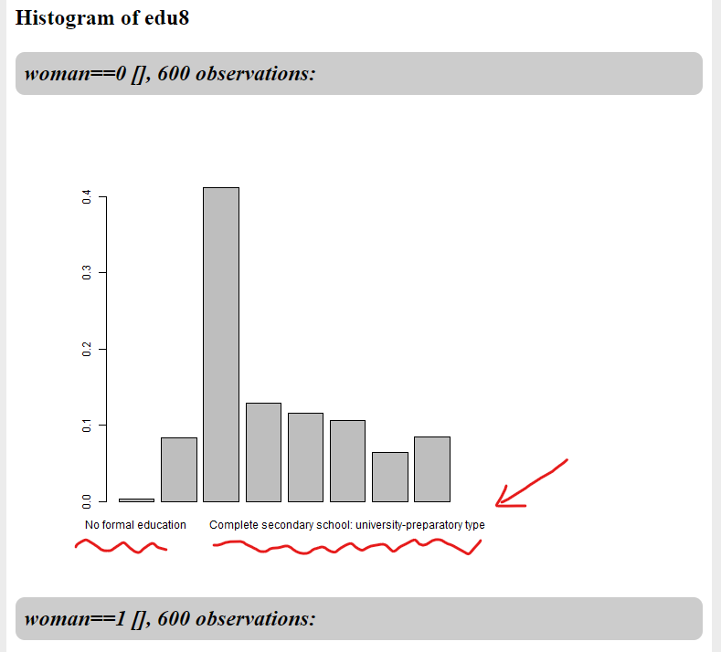

- `summarize`: It works fine, but slightly implemented: ‘mean’ and ‘standard deviation’ values now are rounded at three decimal digits (see Changes and Implementation);
- `browse`: It works fine;
- `scatter`: It works fine;
- `regress`: Overall, it work fine, *unless* the `beta` option is called, that produces an empty output. I’ve not been able to figure out which is the problem, so far (see Issues);
- `scatter`: It work fine;

### Changes and Implementations

- ’_setup.R’: Switch from a list of `install.packages` calls to a wrapper function;
- `summarize`: Now rounds *mean* and *standard deviation* values at three decimal digits;

### Issues

- `regress`: When the `beta` option is included it returns a blank output, only with the header of the table;